# Analiza przestępczości

Stola Barłomiej

2025-10-16

# Analiza przestępczości NYC na podstawie danych o aresztowaniach NYCPD

**Dane:**

- Data
- Rodzaj przestępstwa
- Poziom wykroczenia
- Dzielnica
- Sposób aresztowania
- Cechy demograficzne sprawców (grupa wiekowa, płeć, rasa)

**Problem badawczy:** Czy można wyróżnić grupy przestępstw które będą różniły się między sobą powyższymi cechami i cechami sprawców?

**Hipotezy:**

- H1: Istnieją powiązania pomiędzy typem przestępstwa a sposobem aresztowania
- H2: Typy przestępstw można wyprofilować ze względu na podobieństwa dotyczące okoliczności i cech sprawcy (np. Kradzieże są charakterystyczne dla dzielnicy X dla okresu Y i sposób aresztowania Z, typowy sprawca xyz)
- H3: Struktura przestępstw różni się w zależności od dzielnicy

**EDA - wstępna analiza danych populacyjnych**

Na wstępie przeanalizuję dane populacyjne zawierające informacje odnośnie populacji i liczby przestępców dla każdej rasy (Osoby białe, czarnoskóre, pochodzenia azjatyckiego, pochodzenia latynoskiego i określone przeze mnie jako “Nonwhite” osoby mieszane lub pochodzenia hinduskiego), dla każdej z dzielnic (Bronx, Brooklyn, Manhattan, Queens, Staten Island).

Pierwszy wykres przedstawia stosunek zaaresztowanych (osobno dla każdej rasy) do populacji danej rasy, osobno dla dzielnic.

[figure not shown]

Poniższy wykres przedstawia liczbę przestępców na 1000 mieszkańców w każdej dzielnicy.

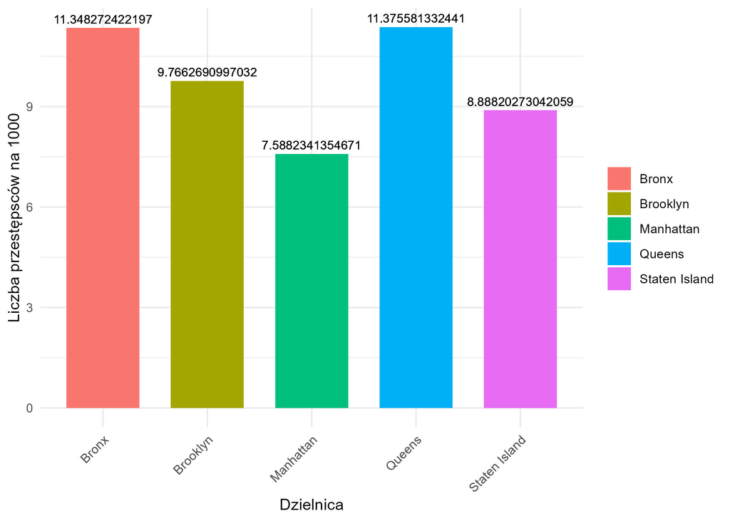

Na poniższych wykresach słupki przedstawiają indeks reprezentacji dla każdej rasy w każdej dzielnicy, gruba przerywana linia reprezentuje średni indeks dla danej rasy, cienka przerywana odchylenie standardowe.

Wyjaśniając czym jest indeks reprezentacji, jest to stosunek udziału danej rasy w przestępstwach do udziału danej rasy w populacji. Indeks równy jeden oznacza przeciętną reprezentację, gdzie wyższe liczby sugerują nadwyżkę.

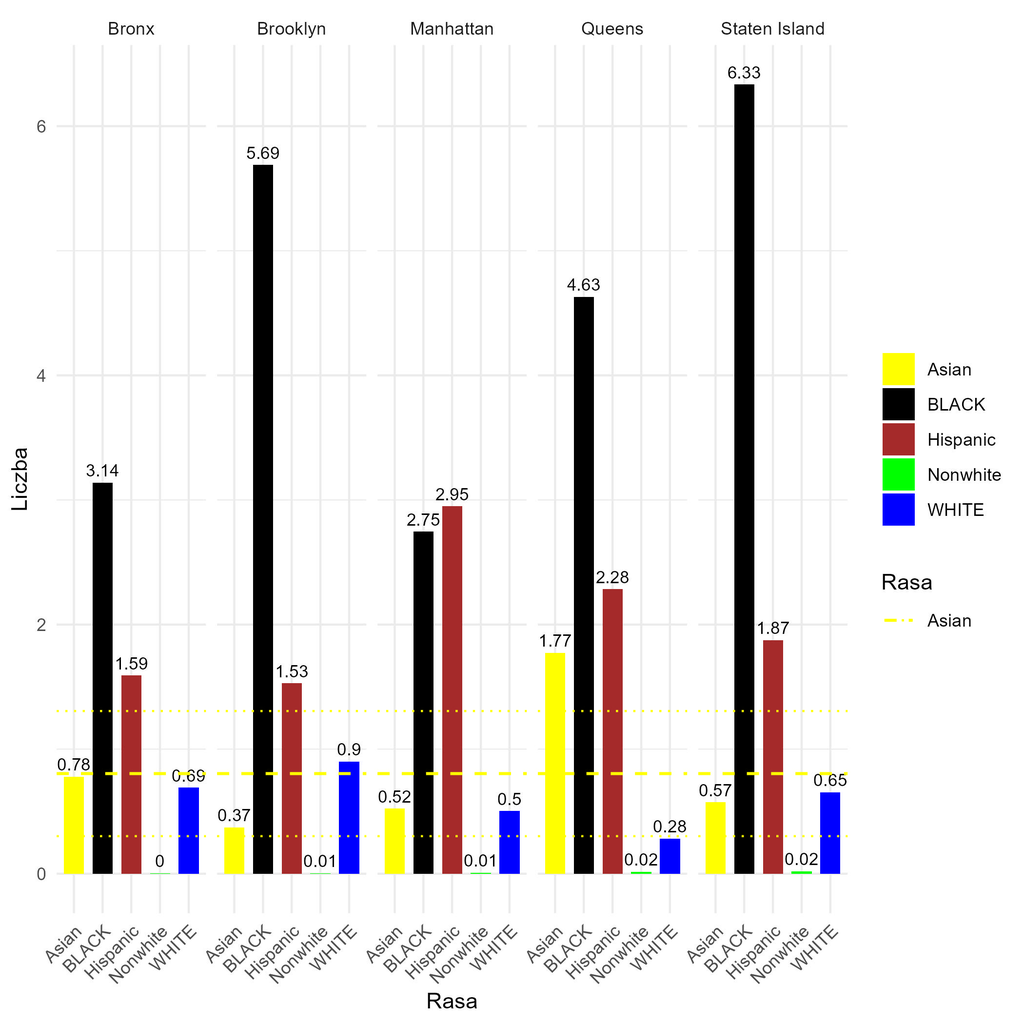

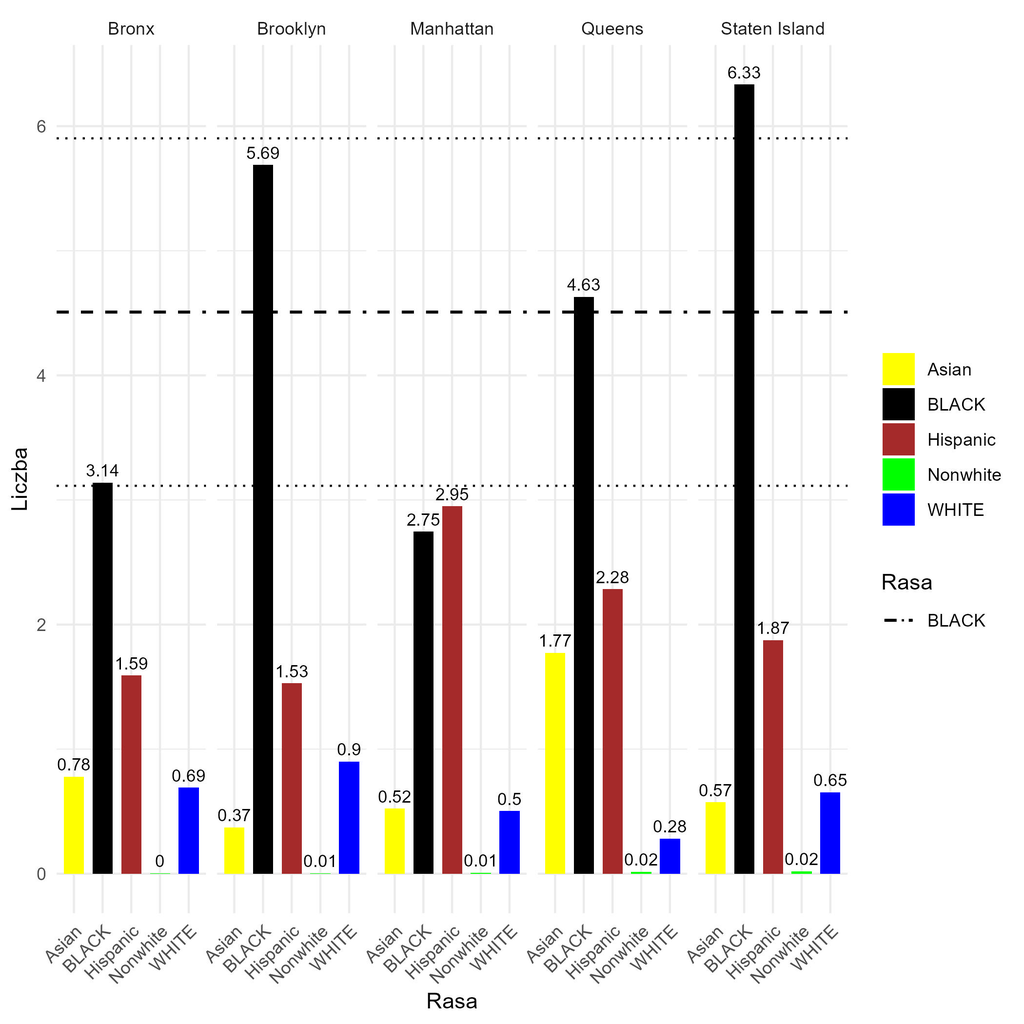

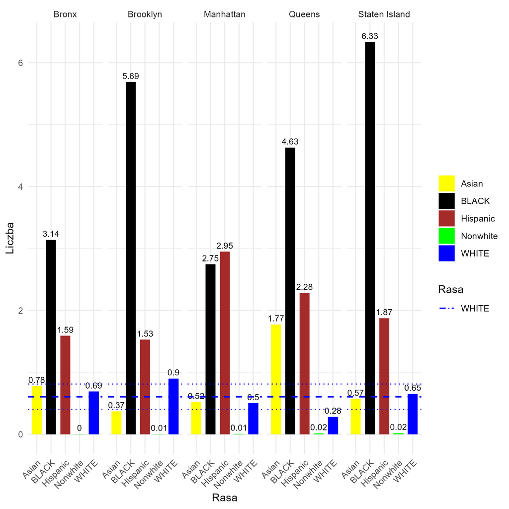

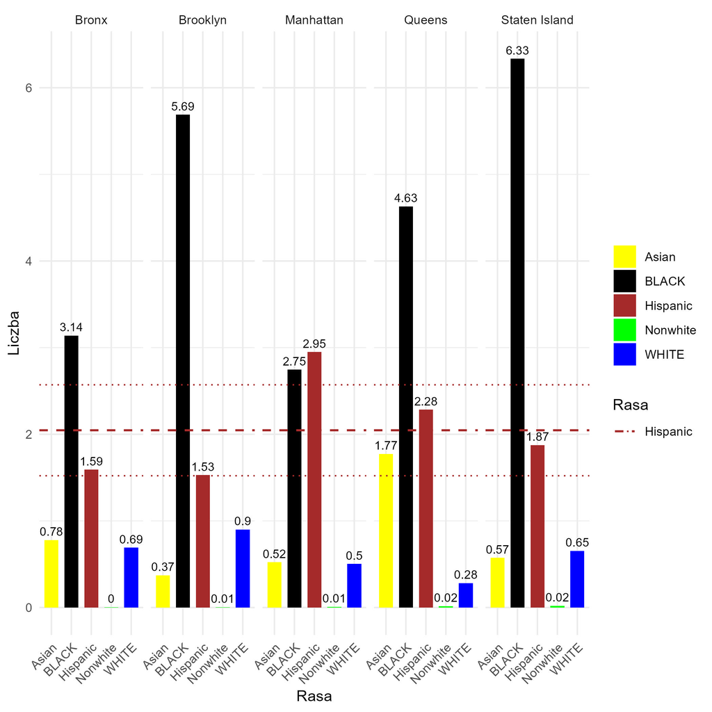

**Czy index reprezentacji jest podobny dla kazdej rasy? Analiza wariancji.**

Na pierwszy rzut oka wartości indeksów rzeczywiście się mocno różnią ale zastosuję analizę wariancji aby uwzględnić ich rozkład i istotność statystyczną.

Założenia:

1. Niezależność obserwacji - Spełnione, rasy i dzielnice są wyodrębnione
2. Normalność reszt - Spełnione na przyjętym poziomie istotności 0.01 brak podstaw do odrzucenia hipotezy o normalności reszt.

```r
anova1 <- aov(indeks ~ perp_race, data = d_all)
shapiro.test(anova1$residuals)
```

```
##
##  Shapiro-Wilk normality test
##
## data:  anova1$residuals
## W = 0.90813, p-value = 0.02769
```

3. Homogenicznosc wariancji - dla przyjętego poziomu istotności odrzucam hipotezę zerową więc brak jednorodności.

   Zastosuję wariant Anovy Bernarda Welcha który jest odporny na brak homogeniczności wariancji.

   ```r
   library(rstatix)
   levene_test(d_all, indeks~perp_race)
   ```

   ```
   ## # A tibble: 1 × 4
   ##     df1   df2 statistic       p
   ##   <int> <int>     <dbl>   <dbl>
   ## 1     4    20      5.66 0.00324
   ```

   ```r
   oneway.test(indeks ~ perp_race,data = d_all, var.equal = FALSE)
   ```

   ```
   ##
   ##  One-way analysis of means (not assuming equal variances)
   ##
   ## data:  indeks and perp_race
   ## F = 29.014, num df = 4.000, denom df = 8.005, p-value = 8.168e-05
   ```

Na poziomie istotności 0.01 odrzucam hipotezę zerową, średnie indeksy reprezentacji różnią się od siebie.

Aby dowiedzieć się więcej o różnicach pomiędzy indeksami reprezentacji wykonam test Gamesa-Howella.

```r
library(rstatix)
library(dplyr)
library(ggplot2)
#Post-hoc
post_hoc<- games_howell_test(d_all, indeks~perp_race, detailed = FALSE)|>
  filter(p.adj.signif!="ns")
kolory <- c("black", "black", "black", "brown","brown","blue")
post_hoc <- post_hoc|>
  mutate(
 axis_group = ifelse(estimate > 0, group1, group2),
    bar_value  = abs(estimate),
 bar_group = ifelse(estimate < 0, group1, group2),
  kolor=kolory)
post_hoc
```

```
## # A tibble: 6 × 12
##   .y.    group1 group2 estimate conf.low conf.high p.adj p.adj.signif axis_group
##   <chr>  <chr>  <chr>     <dbl>    <dbl>     <dbl> <dbl> <chr>        <chr>
## 1 indeks Asian  BLACK     3.70     0.736     6.67  0.021 *            Asian
## 2 indeks BLACK  Nonwh…   -4.50    -7.60     -1.40  0.014 *            Nonwhite
## 3 indeks BLACK  WHITE    -3.90    -6.97     -0.836 0.021 *            WHITE
## 4 indeks Hispa… Nonwh…   -2.03    -3.20     -0.868 0.007 **           Nonwhite
## 5 indeks Hispa… WHITE    -1.44    -2.55     -0.327 0.018 *            WHITE
## 6 indeks Nonwh… WHITE     0.595    0.138     1.05  0.02  *            Nonwhite
## # ℹ 3 more variables: bar_value <dbl>, bar_group <chr>, kolor <chr>
```

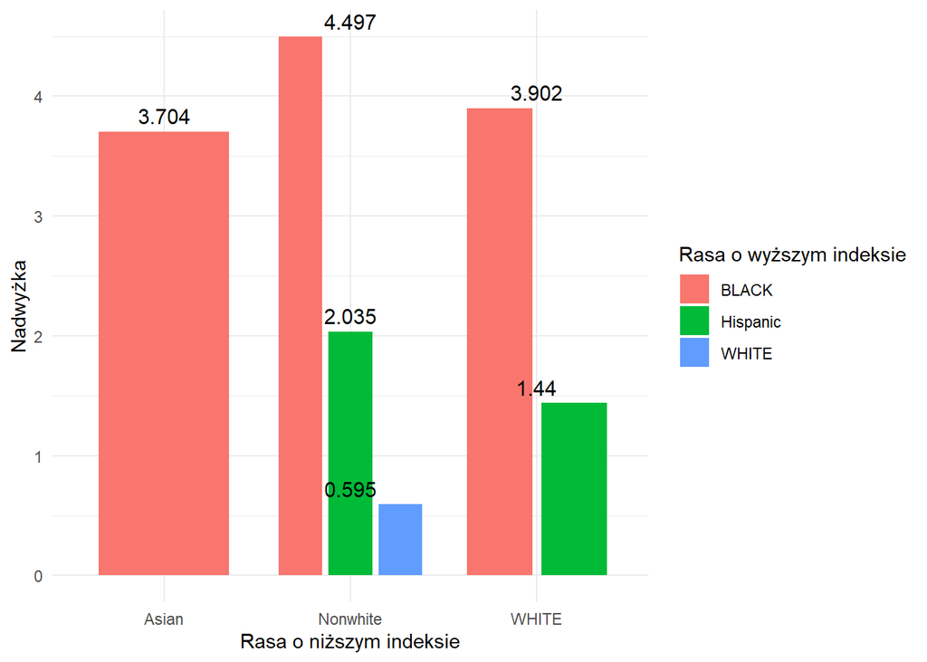

```r
post_hoc_plot <- ggplot(post_hoc, aes(x = axis_group, y = bar_value, fill=bar_group)) +
  geom_col(position = position_dodge(width = 0.8),width=0.7) +
  geom_text(aes(label = round(bar_value, 3)),
            vjust = -0.5, size = 4) +
  labs(
    x = "Rasa o niższym indeksie",
    y = "Nadwyżka",
    fill = "Rasa o wyższym indeksie"
  ) +
  theme_minimal()
ggsave("post_hoc_plot.jpg", post_hoc_plot)
post_hoc_plot
```

**Czy istnieją istotne różnice w indeksach pomiędzy rasami i czy te różnice zależą od dzielnicy? Permutacyjna Anova z interakcją**

```r
library(lmPerm)

model_perm <- aovp(
  indeks ~ perp_race * Distinct,
  data = d_all,
  perm = "Prob"
)
```

```
## [1] "Settings:  unique SS "
```

```r
summary(model_perm)
```

```
## Component 1 :
##                      Df R Sum Sq R Mean Sq Iter Pr(Prob)
## perp_race1            4   64.006   16.0014 5000   <2e-16 ***
## Distinct1             4    1.634    0.4086   51   1.0000
## perp_race1:Distinct1 16   10.937    0.6836 5000   0.0148 *
## ---
## Signif. codes:  0 '***' 0.001 '**' 0.01 '*' 0.05 '.' 0.1 ' ' 1
```

**Wnioski**

Na poziomie istotności α = 0.01 odrzucono hipotezę o równości średnich indeksów dysproporcji pomiędzy rasami. Średnie wartości indeksu istotnie różnią się w zależności od rasy, przy czym efekt ten jest najsilniejszy spośród analizowanych czynników, co potwierdza największa wartość sumy kwadratów.

**Hipotezy**

H1: Istnieją powiązania pomiędzy typem przestępstwa a sposobem aresztowania.

Aby zbadać powyższą hipotezę wykonam zliczę przypadki różnych sposóbów aresztowania dla przestępstw.

```r
macierz
```

```
##
##                                    Patrol Transit Housing
##   ADMINISTRATIVE CODE                  57      26       3
##   ADMINISTRATIVE CODES                  1       0       0
##   ALCOHOLIC BEVERAGE CONTROL LAW      132       0       1
##   ANTICIPATORY OFFENSES               110       0       0
##   ARSON                                22       0       2
##   ASSAULT 3 & RELATED OFFENSES      17918     417     926
##   BURGLAR'S TOOLS                     349      45       5
##   BURGLARY                           3421      10      26
##   CANNABIS RELATED OFFENSES           149       0       5
##   CHILD ABANDONMENT/NON SUPPORT 1      54       0       5
##   CRIMINAL MISCHIEF & RELATED OF     5432     381     259
##   CRIMINAL TRESPASS                  1034     361     274
##   DANGEROUS DRUGS                    9900    1247     607
##   DANGEROUS WEAPONS                  4163     790     188
##   DISORDERLY CONDUCT                   16      51       0
##   ESCAPE 3                              2       1       0
##   FELONY ASSAULT                    10562     162     453
##   FORGERY                            2006     240      37
##   FRAUDS                              400     364      29
##   FRAUDULENT ACCOSTING                 20       3       0
##   GAMBLING                            387       0      10
##   GRAND LARCENY                      4949      93      38
##   GRAND LARCENY OF MOTOR VEHICLE      775       4      10
##   HARRASSMENT 2                        32       2       4
##   HOMICIDE-NEGLIGENT-VEHICLE            1       0       0
##   HOMICIDE-NEGLIGENT,UNCLASSIFIE       10       0       0
##   INTOXICATED & IMPAIRED DRIVING     1350       1      10
##   INTOXICATED/IMPAIRED DRIVING        150       1       3
##   JOSTLING                             11      13       0
##   KIDNAPPING & RELATED OFFENSES        58       0       1
##   LOITERING/GAMBLING (CARDS, DIC        1       0       0
##   MISCELLANEOUS PENAL LAW            8595     205     454
##   MOVING INFRACTIONS                  162       0       4
##   MURDER & NON-NEGL. MANSLAUGHTE      905       6       6
##   NEW YORK CITY HEALTH CODE             0       2       0
##   OFF. AGNST PUB ORD SENSBLTY &      2385      83     151
##   OFFENSES AGAINST PUBLIC ADMINI     3679     842     246
##   OFFENSES AGAINST PUBLIC SAFETY       66       4       2
##   OFFENSES AGAINST THE PERSON         732      87      29
##   OFFENSES INVOLVING FRAUD           1648      20      52
##   OFFENSES RELATED TO CHILDREN         46       0       2
##   OTHER OFFENSES RELATED TO THEFT    1282    6995      10
##   OTHER STATE LAWS                   1737    1750      93
##   OTHER STATE LAWS (NON PENAL LAW)    215      34       3
##   OTHER TRAFFIC INFRACTION           1094       0      46
##   PETIT LARCENY                     13927     105     100
##   POSSESSION OF STOLEN PROPERTY      1769      49      44
##   PROSTITUTION & RELATED OFFENSES     480       0       0
##   RAPE                                438       1      14
##   ROBBERY                            5309      77      73
##   SEX CRIMES                         2868      95     145
##   THEFT-FRAUD                         185       0       0
##   UNAUTHORIZED USE OF A VEHICLE       241       0       6
##   UNLAWFUL POSS. WEAP. ON SCHOOL        1       0       0
##   VEHICLE AND TRAFFIC LAWS           7835       4     326
```

Dla powstałej macierzy wykonuję test niezależności chi.

```r
chisq.test(macierz)
```

```
##
##  Pearson's Chi-squared test
##
## data:  macierz
## X-squared = 66131, df = 108, p-value < 2.2e-16
```

**Wnioski:**

Na poziomie istotności 0.01 odrzucamy hipotezę zerową o niezależności sposobu zaaresztowania z kategorią przestępstwa.

Aby zbadać siłę zależności wykonuję test Haralda Cramera.

```r
library(rstatix)
cramer_v(macierz)
```

```
## [1] 0.4888874
```

Test wskazuje na silną zależność pomiędzy sposobem zaaresztowania a typem przestępstwa.

Poniżej obliczono **standaryzowane reszty (standardized residuals)**. Standaryzowane reszty informują o tym, jak bardzo obserwowana liczba przypadków w danej komórce tabeli różni się od liczby oczekiwanej przy założeniu niezależności, uwzględniając wariancję. Wartości dodatnie wskazują na komórki z większą liczbą obserwacji niż oczekiwano, a wartości ujemne na komórki z mniejszą liczbą obserwacji.

```r
res <- chisq.test(macierz)$stdres
res
```

```
##
##                                           Patrol       Transit       Housing
##   ADMINISTRATIVE CODE                -5.30159403    5.95327243    0.04587016
##   ADMINISTRATIVE CODES                0.40232149   -0.34310993   -0.18757346
##   ALCOHOLIC BEVERAGE CONTROL LAW      4.39147943   -3.95882588   -1.68546145
##   ANTICIPATORY OFFENSES               4.22124665   -3.59998582   -1.96806256
##   ARSON                               0.79204466   -1.68102826    1.33425610
##   ASSAULT 3 & RELATED OFFENSES       30.06060619  -40.77464741   11.63088151
##   BURGLAR'S TOOLS                     0.80870320    0.48597315   -2.36874478
##   BURGLARY                           22.16538725  -19.86927372   -8.69747646
##   CANNABIS RELATED OFFENSES           3.83122387   -4.26023873   -0.10417244
##   CHILD ABANDONMENT/NON SUPPORT 1     1.21067200   -2.63603003    2.15214167
##   CRIMINAL MISCHIEF & RELATED OF      7.80416508  -11.05334282    3.81181518
##   CRIMINAL TRESPASS                 -28.62484099   14.85877235   29.53001505
##   DANGEROUS DRUGS                    -6.02945873    0.28323542   11.04257097
##   DANGEROUS WEAPONS                 -10.74596523   11.50736802    1.04084463
##   DISORDERLY CONDUCT                -14.70392103   17.49293963   -1.53572134
##   ESCAPE 3                           -0.97050361    1.28652987   -0.32488912
##   FELONY ASSAULT                     26.84146774  -32.62791298    3.98114718
##   FORGERY                             2.50179874   -0.03132353   -4.72791748
##   FRAUDS                            -29.05707946   32.53964350    0.40246688
##   FRAUDULENT ACCOSTING                0.12296085    0.39233395   -0.89964227
##   GAMBLING                            6.57621524   -6.84622248   -0.96892786
##   GRAND LARCENY                      23.80832330  -20.58562242  -10.62357490
##   GRAND LARCENY OF MOTOR VEHICLE      9.88969779   -9.20000172   -3.31346326
##   HARRASSMENT 2                      -0.33085698   -1.05829237    2.42515082
##   HOMICIDE-NEGLIGENT-VEHICLE          0.40232149   -0.34310993   -0.18757346
##   HOMICIDE-NEGLIGENT,UNCLASSIFIE      1.27229364   -1.08504417   -0.59317867
##   INTOXICATED & IMPAIRED DRIVING     14.05048168  -12.63186020   -5.45080868
##   INTOXICATED/IMPAIRED DRIVING        4.06406739   -3.99758463   -0.99410895
##   JOSTLING                           -5.69291689    6.96423248   -0.91899495
##   KIDNAPPING & RELATED OFFENSES       2.71488480   -2.63603003   -0.72243665
##   LOITERING/GAMBLING (CARDS, DIC      0.40232149   -0.34310993   -0.18757346
##   MISCELLANEOUS PENAL LAW            19.58513106  -26.98221128    8.28362901
##   MOVING INFRACTIONS                  4.28952623   -4.42330084   -0.70374948
##   MURDER & NON-NEGL. MANSLAUGHTE     11.07542199   -9.77701709   -4.60186923
##   NEW YORK CITY HEALTH CODE          -3.51517116    4.12179527   -0.26526990
##   OFF. AGNST PUB ORD SENSBLTY &       7.45533493  -12.39346436    6.74876623
##   OFFENSES AGAINST PUBLIC ADMINI    -18.04416493   16.32184666    6.83152126
##   OFFENSES AGAINST PUBLIC SAFETY      1.37209969   -1.37606711   -0.29088132
##   OFFENSES AGAINST THE PERSON         0.21255140   -0.25978220    0.03391326
##   OFFENSES INVOLVING FRAUD           11.74499690  -12.73816754   -0.86488722
##   OFFENSES RELATED TO CHILDREN        1.95402807   -2.37753924    0.29365945
##   OTHER OFFENSES RELATED TO THEFT  -191.42196962  225.95563387  -16.98564779
##   OTHER STATE LAWS                  -65.73829817   75.73654960   -2.67990563
##   OTHER STATE LAWS (NON PENAL LAW)   -0.34475179    1.53191689   -1.93642804
##   OTHER TRAFFIC INFRACTION            9.68940571  -11.63271060    1.19060575
##   PETIT LARCENY                      45.21875028  -40.00930599  -18.63319275
##   POSSESSION OF STOLEN PROPERTY      11.21209054  -11.18174223   -2.48326869
##   PROSTITUTION & RELATED OFFENSES     8.82972150   -7.53020962   -4.11666166
##   RAPE                                6.53832820   -7.16133281   -0.36268947
##   ROBBERY                            24.34767780  -22.40206084   -8.57702185
##   SEX CRIMES                         10.11098188  -13.73205772    3.94151738
##   THEFT-FRAUD                         5.47580656   -4.66990621   -2.55297327
##   UNAUTHORIZED USE OF A VEHICLE       5.22510484   -5.39719661   -0.84175854
##   UNLAWFUL POSS. WEAP. ON SCHOOL      0.40232149   -0.34310993   -0.18757346
##   VEHICLE AND TRAFFIC LAWS           26.60406718  -31.81227772    3.05303787
```

Poniższa mapa ciepła przedstawia odchylenia od oczekiwanych wartości, im cieplejszy kolor tym większe dodatnie odchylenie, kolor biały oznacza brak odchylenia.

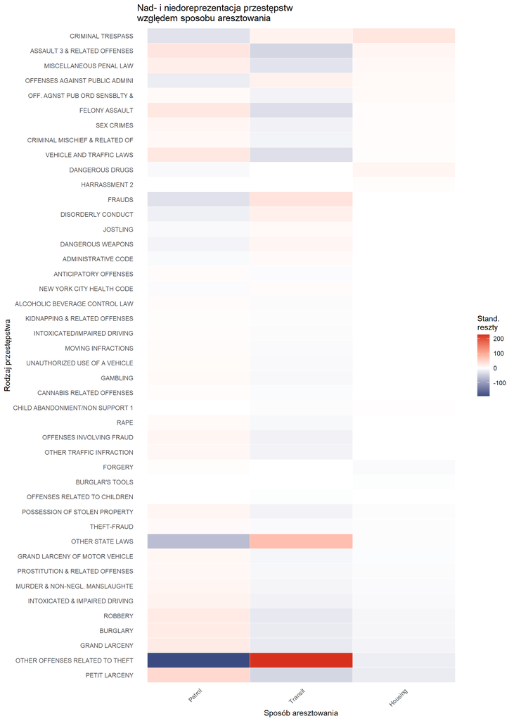

```r
heatmapa
```

**H2:** Typy przestępstw można wyprofilować ze względu na podobieństwa dotyczące okoliczności i cech sprawców (np. kradzieże są typowe dla młodszych sprawców w określonych dzielnicach i porach roku).

Aby zbadać powyższą hipotezę zmodyfikowano pierwotny wzór danych aby zawierał średnie liczby przypadków dla każdej zmiennej osobno dla każdego przestępstwa.

Wyjaśniając jeśli dane przestępstwo zostało popełnione 500 razy a 400 ze sprawców to mężczyźni to średnia dla mężczyzn wynosi 0.8 i tak dla każdej innej zmiennej w tym zmiennych dotyczących czasu popełnienia przestępstwa.

Przestępstwa o zbyt ogólnym opisie zostały usunięte, a utworzone dane znormalizowano (średnia równa 0, odchylenie standardowe równe 1).

```r
zbiór <- zbiór|>
  group_by(ofns_desc)|>
  filter(n()>=200)|>
  filter(ofns_desc!="OTHER STATE LAWS" & ofns_desc!="MISCELLANEOUS PENAL LAW" & ofns_desc!=  "OFFENSES AGAINST THE PERSON" & ofns_desc!= "ASSAULT 3 & RELATED OFFENSES" & ofns_desc!= "OTHER STATE LAWS (NON PENAL LAW)")|>
  ungroup()
profiles <- zbiór%>%
  group_by(ofns_desc) %>%
  summarise(
    # rasa
    p_white   = mean(perp_race == "WHITE"),
    p_black   = mean(perp_race == "BLACK"),
    p_hisp    = mean(perp_race == "Hispanic"),
    p_asian = mean(perp_race=="Asian"),
    p_nonwhite = mean(perp_race=="Nonwhite"),

    # płeć
    p_male    = mean(perp_sex == "M"),
    p_female = mean(perp_sex =="F"),

    # wiek
    p_young   = mean(age_group == "<18" | age_group == "18-24"),
    p_average = mean(age_group =="25-44"),
    p_old = mean(age_group =="45-64"),
    p_v_old =mean(age_group =="65+"),

    # borough
    p_bronx   = mean(Distinct == "Bronx"),
    p_manh    = mean(Distinct == "Manhattan"),
    p_brook   = mean(Distinct == "Brooklyn"),
    p_q = mean(Distinct =="Queens"),
    p_si = mean(Distinct =="Staten Island"),

    # klasyfikacja
    p_felony  = mean(law_cat_cd == "F"),
    p_misdemeanor = mean(law_cat_cd =="M"),
    p_violation = mean(law_cat_cd=="V"),

    # sezon
    p_winter  = mean(season == "Winter"),
    p_spring = mean(season=="Spring"),
    p_summer = mean(season=="Summer")
  )
profiles <- na.omit(profiles)
any(is.na(profiles$ofns_desc))
```

```
## [1] FALSE
```

```r
profiles <- profiles[!is.na(profiles$ofns_desc), ]

any(duplicated(profiles$ofns_desc))
```

```
## [1] FALSE
```

Rozważając hipotezę zastosowano poprawioną metodę klastryzacji hierarchicznej Warda.

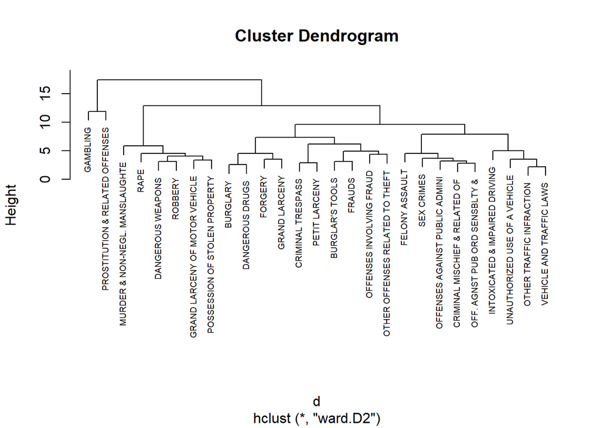

```r
d <- dist(X_scaled)
hc <- hclust(d, method = "ward.D2")
plot(hc, cex = 0.6)
```

Zdecydowałem się podzielić przestępstwa na 5 grup.

```r
clusters <- cutree(hc, k =5)
```

```r
result <- data.frame(
  crime = rownames(X_scaled),
  cluster = clusters
)
```

```r
split(result$crime, result$cluster)
```

```
## $`1`
##  [1] "BURGLAR'S TOOLS"                 "BURGLARY"
##  [3] "CRIMINAL TRESPASS"               "DANGEROUS DRUGS"
##  [5] "FORGERY"                         "FRAUDS"
##  [7] "GRAND LARCENY"                   "OFFENSES INVOLVING FRAUD"
##  [9] "OTHER OFFENSES RELATED TO THEFT" "PETIT LARCENY"
##
## $`2`
## [1] "CRIMINAL MISCHIEF & RELATED OF" "FELONY ASSAULT"
## [3] "INTOXICATED & IMPAIRED DRIVING" "OFF. AGNST PUB ORD SENSBLTY &"
## [5] "OFFENSES AGAINST PUBLIC ADMINI" "OTHER TRAFFIC INFRACTION"
## [7] "SEX CRIMES"                     "UNAUTHORIZED USE OF A VEHICLE"
## [9] "VEHICLE AND TRAFFIC LAWS"
##
## $`3`
## [1] "DANGEROUS WEAPONS"              "GRAND LARCENY OF MOTOR VEHICLE"
## [3] "MURDER & NON-NEGL. MANSLAUGHTE" "POSSESSION OF STOLEN PROPERTY"
## [5] "RAPE"                           "ROBBERY"
##
## $`4`
## [1] "GAMBLING"
##
## $`5`
## [1] "PROSTITUTION & RELATED OFFENSES"
```

1. Grupa

   BURGLAR’S TOOLS → narzędzia włamywacza  
   BURGLARY → włamanie  
   CRIMINAL TRESPASS → bezprawne wtargnięcie  
   DANGEROUS DRUGS → niebezpieczne narkotyki / substancje odurzające  
   FORGERY → fałszerstwo  
   FRAUDS → oszustwa  
   GRAND LARCENY → kradzież o znacznej wartości  
   OFFENSES INVOLVING FRAUD → przestępstwa związane z oszustwem  
   OTHER OFFENSES RELATED TO THEFT → inne przestępstwa związane z kradzieżą  
   PETIT LARCENY → drobna kradzież

   Interpretacja:  
   Bezpośrednia lub pośrednia korzyść majątkowa, brak przemocy fizycznej
2. Grupa

   CRIMINAL MISCHIEF & RELATED OFF → zniszczenie mienia i czyny pokrewne  
   FELONY ASSAULT → ciężkie pobicie / napaść  
   INTOXICATED & IMPAIRED DRIVING → prowadzenie pod wpływem alkoholu lub narkotyków  
   OFF. AGNST PUB ORD SENSBLTY & → przestępstwa przeciwko porządkowi publicznemu i obyczajności  
   OFFENSES AGAINST PUBLIC ADMINI → przestępstwa przeciwko administracji publicznej  
   OTHER TRAFFIC INFRACTION → inne wykroczenia drogowe  
   SEX CRIMES → przestępstwa seksualne  
   UNAUTHORIZED USE OF A VEHICLE → nieuprawnione użycie pojazdu  
   VEHICLE AND TRAFFIC LAWS → naruszenia prawa drogowego

   Interpretacja:  
   Naruszenia porządku publicznego, norm społecznych i przepisów administracyjnych
3. Grupa

   DANGEROUS WEAPONS → niebezpieczna broń  
   GRAND LARCENY OF MOTOR VEHICLE → kradzież pojazdu  
   MURDER & NON-NEGL. MANSLAUGHTER → zabójstwo i nieumyślne spowodowanie śmierci  
   POSSESSION OF STOLEN PROPERTY → posiadanie skradzionego mienia  
   RAPE → gwałt  
   ROBBERY → rozbój

   Interpretacja:  
   Wysoka szkodliwość społeczna, przemoc fizyczna lub zagrożenie życia i zdrowia
4. Grupa

   GAMBLING → hazard

   Interpretacja:  
   Nielegalna działalność związana z grami losowymi
5. Grupa

   PROSTITUTION & RELATED OFFENSES → prostytucja i przestępstwa powiązane

   Interpretacja: Naruszenie norm obyczajowych i regulacji prawnych dotyczących prostytucji

```r
cluster_profiles <- aggregate(
  X_scaled,
  by = list(cluster = clusters),
  FUN = mean
)
```

```r
cluster_profiles
```

```
##   cluster    p_white     p_black      p_hisp    p_asian p_nonwhite     p_male
## 1       1  0.4990709  0.12502424  0.01188557 -0.2771772 -0.3327032  0.2115467
## 2       2  0.2039057  0.01794993  0.21885919 -0.2182419  0.2400328 -0.3805041
## 3       3 -0.5143717  0.58893326 -0.11850862 -0.3043010 -0.5018881  0.8216863
## 4       4 -2.0625930 -2.25885720 -2.70360082  4.3841297  0.5875494 -0.7032413
## 5       5 -1.6770373 -2.68653409  1.32606415  2.1776254  3.5905160 -2.9178072
##     p_female    p_young  p_average      p_old     p_v_old    p_bronx     p_manh
## 1 -0.2115467 -0.4493112  0.1380862  0.5468500  0.02349028 -0.4259744  1.0892938
## 2  0.3805041 -0.2966154  0.8268001 -0.4423757 -0.13121908  0.2710581 -0.5946711
## 3 -0.8216863  1.4971826 -1.2320993 -0.8819326 -0.53080727  0.9823238 -0.3971041
## 4  0.7032413 -1.0864337 -1.8174590  3.0627591  4.28545732 -1.5240447 -1.6683757
## 5  2.9178072 -0.7340111  0.3879918  0.7417183 -0.15454478 -2.5496773 -1.4898983
##       p_brook        p_q       p_si   p_felony p_misdemeanor p_violation
## 1 -0.24679967 -0.3991581 -0.2203230 -0.1065857     0.1065857         NaN
## 2  0.10563950  0.1029840  0.8775083 -0.4768817     0.4768817         NaN
## 3 -0.06227965 -0.1749619 -0.4419032  1.0643594    -1.0643594         NaN
## 4  4.07375490 -0.3448404 -1.7047909 -0.4240011     0.4240011         NaN
## 5 -2.18283575  4.4593359 -1.3381352 -0.6043625     0.6043625         NaN
##      p_winter   p_spring   p_summer
## 1  0.60669257 -0.3930627 -0.7141168
## 2  0.04466138 -0.2244917  0.3281867
## 3 -0.33203567  0.1774054  0.4642567
## 4 -2.33955669  2.7929400  0.2670690
## 5 -2.13710741  2.0936807  1.1348788
```

```r
klastry<- round(cluster_profiles, 3)
rasy <- c("p_white", "p_black","p_hisp","p_asian","p_nonwhite")
płcie <- c("p_male","p_female")
wiek <- c("p_young","p_average","p_old","p_v_old")
dzielnice <- c("p_bronx","p_manh","p_brook","p_q","p_si")
waga <- c("p_felony","p_misdemeanor","p_violation")
sezon <- c("p_winter","p_spring","p_summer")

scale_block <- function(df, cols){
  df[, cols] <- scale(df[, cols])
  df
}
klastry_scaled <- klastry
klastry_scaled <- scale_block(klastry_scaled, rasy)
klastry_scaled <- scale_block(klastry_scaled, płcie)
klastry_scaled <- scale_block(klastry_scaled, wiek)
klastry_scaled <- scale_block(klastry_scaled, dzielnice)
klastry_scaled <- scale_block(klastry_scaled, waga)
klastry_scaled <- scale_block(klastry_scaled, sezon)
```

W celu zapewnienia porównywalności zmiennych i uniknięcia dominacji bloków o większej liczbie cech, zastosowano skalowanie **w obrębie poszczególnych bloków zmiennych**. Zmienna `klastry` została poddana transformacji za pomocą funkcji `scale_block`, która normalizuje wartości każdej zmiennej w danym bloku poprzez odjęcie średniej i podzielenie przez odchylenie standardowe.

Skalowanie przeprowadzono oddzielnie dla następujących bloków:

**rasy**

**płci**

**wieku**

**dzielnic**

**wagi przestępstw**

**sezonu ( zima, wiosna, lato brak danych dla jesieni)**

Dzięki takiemu podejściu każda zmienna w obrębie bloku ma średnią równą 0 i odchylenie standardowe równe 1. Ponadto, skalowanie blokowe zapewnia, że **żaden blok zmiennych nie ma nieproporcjonalnie większego wpływu na odległość między obserwacjami**, co jest szczególnie istotne w analizie klasteryzacji opartej na metryce euklidesowej.

Poniższa Tabela przedstawia **zestawienie wartości standaryzowanych (z-score)** dla zmiennych użytych w analizie klasteryzacji. Każda komórka zawiera wartość znormalizowaną dla konkretnej obserwacji i zmiennej.

Kolorowanie jest stosowane globalnie względem **całej tabeli**, tzn. skala kolorów jest ustalona na podstawie **największej wartości bezwzględnej** spośród wszystkich komórek. Dzięki temu wartości są porównywalne między kolumnami.

**Kolor czerwony** oznacza wartości **silnie ujemne** (poniżej średniej).

**Kolor żółty** oznacza wartości **bliskie średniej**.

**Kolor zielony** oznacza wartości **silnie dodatnie** (powyżej średniej).

Co pomaga w poniższym profilowaniu.

```r
library(knitr)
library(kableExtra)
library(scales)
klastry_scaled <- klastry_scaled[,-c(1,20)]
num_cols <- klastry_scaled
max_abs <- max(abs(as.matrix(num_cols)), na.rm = TRUE)
pal_global <- scales::col_numeric(
  palette = c("red", "yellow", "green"),
  domain = c(-max_abs, max_abs)
)
kbl <- kable(klastry_scaled, digits = 3, format = "html") %>%
  kable_styling(full_width = FALSE)

for(i in 1:ncol(klastry_scaled)){
  bg <- pal_global(klastry_scaled[[i]])
  kbl <- kbl %>% column_spec(i, background = bg)
}

kbl
```

| p_white | p_black | p_hisp | p_asian | p_nonwhite | p_male | p_female | p_young | p_average | p_old | p_v_old | p_bronx | p_manh | p_brook | p_q | p_si | p_felony | p_misdemeanor | p_winter | p_spring | p_summer |
| --- | --- | --- | --- | --- | --- | --- | --- | --- | --- | --- | --- | --- | --- | --- | --- | --- | --- | --- | --- | --- |
| 1.071 | 0.640 | 0.179 | -0.683 | -0.630 | 0.566 | -0.566 | -0.235 | 0.423 | -0.038 | -0.335 | 0.159 | 1.549 | -0.256 | -0.538 | 0.341 | 0.004 | -0.004 | 1.082 | -0.881 | -1.525 |
| 0.810 | 0.570 | 0.318 | -0.655 | -0.286 | 0.149 | -0.149 | -0.083 | 1.033 | -0.684 | -0.411 | 0.653 | 0.016 | -0.101 | -0.299 | 1.423 | -0.539 | 0.539 | 0.659 | -0.765 | 0.048 |
| 0.174 | 0.947 | 0.090 | -0.696 | -0.732 | 0.994 | -0.994 | 1.706 | -0.791 | -0.972 | -0.610 | 1.158 | 0.196 | -0.175 | -0.431 | 0.122 | 1.723 | -1.723 | 0.376 | -0.490 | 0.254 |
| -1.198 | -0.937 | -1.651 | 1.543 | -0.077 | -0.077 | 0.077 | -0.870 | -1.309 | 1.605 | 1.780 | -0.621 | -0.961 | 1.636 | -0.513 | -1.124 | -0.462 | 0.462 | -1.135 | 1.308 | -0.044 |
| -0.856 | -1.220 | 1.064 | 0.490 | 1.726 | -1.632 | 1.632 | -0.519 | 0.644 | 0.089 | -0.423 | -1.349 | -0.799 | -1.104 | 1.781 | -0.762 | -0.726 | 0.726 | -0.982 | 0.828 | 1.267 |

### Wnioski

**Przestępstwa porządkowe, administracyjne oraz naruszenia przepisów ruchu drogowego** dotyczą głównie mężczyzn rasy białej oraz czarnoskórych, przy czym udział kobiet jest mniejszy, lecz bez wyraźnego kontrastu. Dominują osoby w wieku 25–44 lat, pochodzące przede wszystkim ze Staten Island, a w mniejszym stopniu z Bronx. Zdarzenia te mają średni poziom szkodliwości i występują głównie zimą, rzadziej latem, a prawie w ogóle nie występują wiosną.

**Przestępstwa z użyciem przemocy lub nielegalnym posiadaniem broni** są silnie skorelowane z mężczyznami rasy czarnej, z niewielkim udziałem osób białych oraz praktycznie bez udziału kobiet. Najczęściej sprawcy są w przedziale 18–24 lat lub nieletni. Kategoria ta obejmuje przestępstwa o najwyższej wadze, z dominującym miejscem popełnienia w dzielnicy Bronx. Częstotliwość zdarzeń jest najwyższa w sezonie zimowym oraz latem, przy zbliżonych wartościach dla obu okresów.

**Przestępstwa hazardowe** wykazują silną zależność od pochodzenia azjatyckiego, przy jednoczesnym wyraźnym kontraście w stosunku do osób białych oraz pochodzenia latynoskiego. Udział kobiet jest większy niż mężczyzn, choć różnica nie jest istotna. Przeważają osoby w wieku 44–65 lat, a w jeszcze większym stopniu 65+. Przestępstwa te mają średni poziom ciężkości i są popełniane głównie na Brooklynie, z wyraźną przewagą sezonu wiosennego.

**Przestępstwa związane z prostytucją i przestępstwa powiązane** dotyczą przede wszystkim osób pochodzenia latynoskiego oraz osób mieszanych rasowo (w tym m.in. mieszanki latynoskiej, czarnoskórej i białej, a także osób pochodzenia hinduskiego). Zdecydowanie rzadziej dotyczą osób azjatyckich, a praktycznie nie obejmują osób białych i czarnoskórych. Sprawcy są w większości kobietami w wieku 25–44 lat, rzadziej w wieku 44–65 lat. Przestępstwa te mają średni poziom ciężkości i występują praktycznie wyłącznie w dzielnicy Queens, przede wszystkim w sezonie letnim i wiosennym.

# Model

Zbudowano model Random Forest w celu predykcji grupy przestępstw na podstawie cech demograficznych sprawców oraz kontekstu aresztowania. Zbiór danych podzielono na część treningową (90%) i testową (10%). Jako miarę jakości przyjęto trafność klasyfikacji oraz macierz pomyłek. Dodatkowo przeanalizowano ważność zmiennych.

Random Forest aproksymuje funkcję maksymalizującą prawdopodobieństwo przynależności obserwacji do klastra poprzez głosowanie wielu drzew decyzyjnych budowanych na losowych próbkach danych i cech.

```r
map_clusters <- data.frame(
  ofns_desc = result$crime,
  cluster = as.integer(result$cluster)
)

data_ml <- zbiór %>%
  left_join(map_clusters, by="ofns_desc")
data_ml <- data_ml %>%
  select(cluster,
         age_group,
         perp_sex,
         perp_race,
         Distinct,
         season,
         Arrest_manner)
data_ml <- data_ml %>%
  mutate(across(everything(), as.factor))

set.seed(123)

id_train <- sample(
  1:nrow(data_ml),
  size = 0.9 * nrow(data_ml)
)

train <- data_ml[id_train, ]
test  <- data_ml[-id_train, ]


library(randomForest)
rf_model <- randomForest(
  cluster ~ .,
  data = train,
  ntree = 500,
  importance = TRUE
)
summary(rf_model)
```

```
##                 Length Class  Mode
## call                 5 -none- call
## type                 1 -none- character
## predicted        93355 factor numeric
## err.rate          3000 -none- numeric
## confusion           30 -none- numeric
## votes           466775 matrix numeric
## oob.times        93355 -none- numeric
## classes              5 -none- character
## importance          42 -none- numeric
## importanceSD        36 -none- numeric
## localImportance      0 -none- NULL
## proximity            0 -none- NULL
## ntree                1 -none- numeric
## mtry                 1 -none- numeric
## forest              14 -none- list
## y                93355 factor numeric
## test                 0 -none- NULL
## inbag                0 -none- NULL
## terms                3 terms  call
```

```r
pred <- predict(rf_model, newdata = test)
```

**Ocena jakości**

```r
confusionMatrix <- table(pred, test$cluster)
confusionMatrix
```

```
##
## pred    1    2    3    4    5
##    1 3134 1280  487   12   11
##    2 1756 2509  757   21   39
##    3   80   81  206    0    0
##    4    0    0    0    0    0
##    5    0    0    0    0    0
```

```r
sum(diag(confusionMatrix))/sum(confusionMatrix)
```

```
## [1] 0.5638677
```

Dokładność wynosi 56%

Przykładowy nowy przypadek (testowy) należący do czwartej grupy dosłownie ze zbioru treningowego.

```r
new <- data.frame(
  age_group = "25-44",
  perp_sex  = "M",
  perp_race = "Asian",
  Distinct   = "Brooklyn",
  season    = "Summer",
  Arrest_manner = "Patrol"
)
for(col in intersect(names(train), names(new))) {
  if(is.ordered(train[[col]])) {
    new[[col]] <- factor(new[[col]],
                         levels = levels(train[[col]]),
                         ordered = TRUE)
  } else if(is.factor(train[[col]])) {
    new[[col]] <- factor(new[[col]],
                         levels = levels(train[[col]]))
  }
}

pred_class <- predict(rf_model, newdata = new)
pred_probs0 <- predict(rf_model, newdata = new, type = "prob")
pred_train0 <- predict(rf_model, train)

pred_probs0
```

```
##      1    2 3 4 5
## 1 0.47 0.53 0 0 0
## attr(,"class")
## [1] "matrix" "array"  "votes"
```

```r
table(train$cluster)
```

```
##
##     1     2     3     4     5
## 44604 34786 13171   364   430
```

```r
freq <- table(train$cluster)
w <-c(2.1,2.45,2.35,2.1,2.02)
```

**Nowy model**

```r
rf_w <- randomForest(
  cluster ~ .,
  data = train,
  ntree = 500,
  classwt = w
)

pred_class <- predict(rf_w, newdata = new)
pred_probs <- predict(rf_w, newdata = new, type = "prob")
pred_train <- predict(rf_w, newdata=train)
table(pred_train, train$cluster)
```

```
##
## pred_train     1     2     3     4     5
##          1 20684  6400  2434     7     8
##          2 15335 18942  5033    62    56
##          3  3552  3963  4308    22     6
##          4  1400  1378   383   232    23
##          5  3633  4103  1013    41   337
```

```r
pred_class
```

```
## 1
## 4
## Levels: 1 2 3 4 5
```

Model przewidział przypadek poprawnie ale sprawdzę jego jakość.

```r
pred_test <- predict(rf_w, newdata = test)
tab <- table(pred_test, test$cluster)
recall <- diag(prop.table(tab, 2))
recall
```

```
##         1         2         3         4         5
## 0.4517103 0.5490956 0.3400000 0.7272727 0.8000000
```

Czułość - stosunek prawdziwie pozytywnych przypadków do sumy prawdziwie pozytywnych i fałszywie negatywnych, czyli jak często model rzeczywiście przewidział grupę jest moim zdaniem zadowalająca.

Test precyzji - jaki jest stosunek poprawnych przewidywań danej grupy w stosunku ogólnie do przewidywań tej grupy.

```r
precision <- diag(prop.table(tab, 1))
precision
```

```
##          1          2          3          4          5
## 0.70508794 0.48055179 0.36170213 0.06703911 0.03824092
```

Model zbyt często przewiduje grupę czwartą i piątą jednak tylko 6% i 4% trafnie.

Średnia czułość i precyzja:

```r
mean(recall)
```

```
## [1] 0.5736157
```

```r
mean(precision)
```

```
## [1] 0.3305244
```

Ogólna dokładność modelu

```r
sum(diag(tab))/sum(tab)
```

```
## [1] 0.4749831
```

Dokładność nowego modelu jest niższa niż poprzedniego ale przynajmniej był w stanie przewidzieć grupy 4 i 5.